# proj2

Before you turn this assignment in, make sure everything runs as expected. First, **restart the kernel** (in the menubar, select Kernel$\rightarrow$Restart) and then **run all cells** (in the menubar, select Cell$\rightarrow$Run All). Lastly, hit **Validate**.

If you worked locally, and then uploaded your work to the hub, make sure to follow these steps:

- open your uploaded notebook **on the hub**
- hit the validate button right above this cell, from inside the notebook

These steps should solve any issue related to submitting the notebook on the hub.

Make sure you fill in any place that says `YOUR CODE HERE` or "YOUR ANSWER HERE", as well as your name and collaborators below:

```python
NAME = "Jhinuk Barman"
COLLABORATORS = "Krutika Ingale"
```

# Project 2: Spam // Ham Prediction

## Due Date: 11:59pm Sunday, April 29

In this project, you will use what you've learned in class to create a classifier that can distinguish spam (junk or commercial or bulk) emails from ham (non-spam) emails. In addition to providing some skeleton code to fill in, we will evaluate your work based on your model's accuracy and your written responses in this notebook.

## Score breakdown

| Question | Points |
| --- | --- |
| Question 1 | 3 |
| Question 2 | 2 |
| Question 3a | 2 |
| Question 3b | 2 |
| Question 4 | 2 |
| Question 5 | 2 |
| Question 6 | 9 |
| Question 7 | 6 |
| Question 8 | 6 |
| Question 9 | 3 |
| Question 10 | 5 |
| Total | 42 |

# Part I - Initial Analysis

```python
import numpy as np
import pandas as pd

import matplotlib.pyplot as plt
%matplotlib inline

import seaborn as sns
sns.set(style = "whitegrid",
        color_codes = True,
        font_scale = 1.5)
```

### Loading in the Data

The dataset consists of email messages and their labels (0 for ham, 1 for spam). Your labelled dataset contains 8348 labelled examples, and the evaluation set contains 1000 unlabelled examples.

Run the following cells to load in the data into DataFrames.

The `evaluation` DataFrame contains another set of 1000 unlabelled examples. You will predict labels for these examples and submit your predictions to Kaggle for evaluation.

```python
from utils import fetch_and_cache_gdrive
fetch_and_cache_gdrive('1SCASpLZFKCp2zek-toR3xeKX3DZnBSyp', 'train.csv')
fetch_and_cache_gdrive('1ZDFo9OTF96B5GP2Nzn8P8-AL7CTQXmC0', 'eval.csv')

original_training_data = pd.read_csv('data/train.csv')
evaluation = pd.read_csv('data/eval.csv')

# Convert the emails to lower case as a first step to processing the text
original_training_data['email'] = original_training_data['email'].str.lower()
evaluation['email'] = evaluation['email'].str.lower()

original_training_data.head()
```

```
Using version already downloaded: Tue Apr 17 17:41:32 2018
MD5 hash of file: 0380c4cf72746622947b9ca5db9b8be8
Using version already downloaded: Tue Apr 17 17:41:33 2018
MD5 hash of file: a2e7abd8c7d9abf6e6fafc1d1f9ee6bf
```

|  | id | subject | email | spam |
| --- | --- | --- | --- | --- |
| 0 | 0 | Subject: A&L Daily to be auctioned in bankrupt... | url: http://boingboing.net/#85534171\n date: n... | 0 |
| 1 | 1 | Subject: Wired: "Stronger ties between ISPs an... | url: http://scriptingnews.userland.com/backiss... | 0 |
| 2 | 2 | Subject: It's just too small ... | <html>\n <head>\n </head>\n <body>\n <font siz... | 1 |
| 3 | 3 | Subject: liberal defnitions\n | depends on how much over spending vs. how much... | 0 |
| 4 | 4 | Subject: RE: [ILUG] Newbie seeks advice - Suse... | hehe sorry but if you hit caps lock twice the ... | 0 |

## Train-Test Split

The training data we downloaded is all the data we have available for both training models and **testing** the models that we train. We therefore need to split the training data into separate training and test datsets. You will need this **test data** to evaluate your model once you are finished training.

```python
from sklearn.model_selection import train_test_split

[train, test] = train_test_split(original_training_data, test_size=0.1, random_state=42)
```

# Question 1

In the cell below, print the text of the first ham and the first spam email in the training set. Then, discuss one thing you notice that is different between the two that might relate to the identification of spam.

```python
# Print the text of the first ham and the first spam emails. Then, fill in your response in the q01 variable:
first_ham = train.iloc[0]['email']
first_spam = train.iloc[5]['email']

print(first_ham + "***********************")
print(first_spam)
# YOUR CODE HERE
#raise NotImplementedError()
```

```
while i was playing with the past issues, it annoyed me that there was
 no easy way to make the log stop growing (i don't mean to truncate it,
 i mean to just freeze it for a while).

 the following patch adds a new button to the log window, which allows
 the log to be switched on/off (the button says "disable" when the
 log is enabled, and the button disables it, and "enable" when the log
 is frozen, and the button enables it again).

 kre

 --- main.tcl	wed aug 21 15:01:48 2002
 +++ /usr/local/lib/exmh-2.5/main.tcl	wed aug 28 17:36:59 2002
 @@ -385,6 +385,9 @@
  	exmhlogcreate
  	wm withdraw $exmh(logtop)
      }
 +    if {! $exmh(logwrite)} {
 +	return
 +    }
      if [info exists exmh(log)] {
  	catch {
  #	    $exmh(log) insert end " [bw_delta] "
 @@ -407,6 +410,9 @@
      set exmh(logwindow) 1
      exwin_toplevel .log "exmh log" log
      set exmh(logtop) .log
 +    set exmh(logdisablebut) \
 +	[widget_addbut $exmh(logtop).but swap "disable" exmhlogtoggle]
 +    set exmh(logwrite) 1
      widget_addbut $exmh(logtop).but trunc "truncate" exmhlogtrunc
      widget_addbut $exmh(logtop).but save "save to file" exmhlogsave
      set exmh(logyview) 1
 @@ -457,6 +463,12 @@
      } msg] {
  	exmh_status "cannot save log: $msg" error
      }
 +}
 +proc exmhlogtoggle {} {
 +    global exmh
```

[output cut: 42 more lines]

```

 best regards=2c

 aluko martin=2e

 --


 --===_secatt_000_1fuklemuttfusq
 content-type: application/octet-stream; name="mailxs_list.lst"
 content-transfer-encoding: base64
 content-disposition: attachment; filename="mailxs_list.lst"


 --===_secatt_000_1fuklemuttfusq
```

```python
# This is a cell with just a comment but don't delete me if you want to get credit.
```

The spam email has random integers placed throughout the email such as "$34=2c700=2c000" whereas the ham email does not have this inside the body of the email.

# Basic Feature Engineering

We would like to take the text of an email and predict whether the text is ham or spam. This is a *classification* problem, so we can use logistic regression to make a classifier. Recall that to train an logistic regression model we need a numeric feature matrix $\Phi$ (pronounced phi as in wifi) and corresponding binary labels $Y$. Unfortunately, our data are text, not numbers. To address this, we can create numeric features derived from the email text and use those features for logistic regression.

Each row of $\Phi$ is derived from one email example. Each column of $\Phi$ is one feature. We'll guide you through creating a simple feature, and you'll create more interesting ones when you are trying to increase your accuracy.

# Question 2

Create a function called `words_in_texts` that takes in a list of `words` and a pandas Series of email `texts`. It should output a 2-dimensional NumPy array containing one row for each email text. The row should contain either a 0 or a 1 for each word in the list: 0 if the word doesn't appear in the text and 1 if the word does. For example:

```
>>> words_in_texts(['hello', 'bye', 'world'],
                   pd.Series(['hello', 'hello world hello']))

array([[1, 0, 0],
       [1, 0, 1]])
```

```python
def words_in_texts(words, texts):
    '''
    Args:
        words (list-like): words to find
        texts (Series): strings to search in

    Returns:
        NumPy array of 0s and 1s with shape (n, p) where n is the
        number of texts and p is the number of words.
    '''
    indicator_array = [int(word in text) for text in texts for word in words]
    # YOUR CODE HERE
    #raise NotImplementedError()
    indicator_array = np.array_split(np.array(indicator_array), len(texts))
    return np.array(indicator_array)

words_in_texts(['hello', 'bye', 'world'],
                   pd.Series(['hello', 'hello world hello']))
```

```
array([[1, 0, 0],
       [1, 0, 1]])
```

```python
# If this doesn't error, your function outputs the correct output for this example
assert np.allclose(words_in_texts(['hello', 'bye', 'world'],
                                  pd.Series(['hello', 'hello world hello'])),
                   np.array([[1, 0, 0],
                             [1, 0, 1]]))
```

# Basic EDA

Now we need to identify some features that allow us to tell spam and ham emails apart. One idea is to compare the distribution of a single feature in spam emails to the distribution of the same feature in ham emails. If the feature is itself a binary indicator, such as whether a certain word occurs in the text, this amounts to comparing the proportion of spam emails with the word to the proportion of ham emails with the word.

# Question 3a

Create a bar chart comparing the proportion of spam and ham emails containing certain words. It should look like the following plot (which was created using `sns.barplot`), but you should choose your own words as candidate features.

[figure not shown]

```
(0, 1)
```

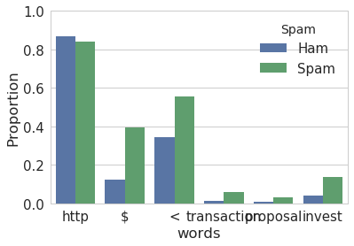

```python
# YOUR CODE HERE
words = ['http', '$', '<', 'transaction', 'proposal', 'invest']
#words = ['body', 'business', 'html', 'money', 'offer', 'please']
p = pd.DataFrame(train['spam'])
ham = train[train['spam'] == 0]
spam = train[train['spam'] == 1]
transposed_ham = words_in_texts(words, ham['email']).T
transposed_spam = words_in_texts(words, spam['email']).T
prop_ham = [sum(i)/len(ham) for i in transposed_ham]
prop_spam = [sum(i)/len(spam) for i in transposed_spam]


final = pd.DataFrame(data = {'words': words + words,
                             'Proportion': np.append(prop_ham, prop_spam),
                            'Spam': np.append(np.repeat('Ham', len(words)), np.repeat('Spam', len(words)))})
final

sns.barplot(x = 'words', y = 'Proportion', hue='Spam', data=final)
plt.ylim(0, 1)

#raise NotImplementedError()
```

# Question 3b

When the feature is binary, it makes sense (as in the previous question) to compare the proportion of 1s in the two classes of email. Otherwise, if the feature can take on many values, it makes sense to compare the distribution under spam to the distribution under ham. Create a *class conditional density plot* like the one below (which was created using `sns.distplot`), comparing the distribution of a feature among all spam emails to the distribution of the same feature among all ham emails. **You may use the Fraction of Uppercase Letters or create your own feature.**

[figure not shown]

```
Text(0.5,0,'Fraction of Uppercase Letters in Email')
```

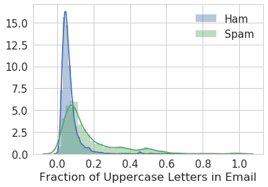

```python
# YOUR CODE HERE
training_data = pd.read_csv('data/train.csv')
ham_data = training_data[training_data['spam'] == 0]
spam_data = training_data[training_data['spam'] == 1]
proportion_ham = (ham_data['email'].str.findall('[A-Z]').str.len() / ham_data['email'].str.findall('[a-zA-Z]').str.len())
proportion_spam = (spam_data['email'].str.findall('[A-Z]').str.len() / spam_data['email'].str.findall('[a-zA-Z]').str.len())

sns.distplot(proportion_ham, label = 'Ham')
sns.distplot(proportion_spam, label = 'Spam')
plt.legend()
plt.xlabel('Fraction of Uppercase Letters in Email')

#proportion_ham
#ham_data['email'].str.findall('[A-Z]').str.len() / ham_data['email'].str.findall('[a-zA-Z]').str.len()
#raise NotImplementedError()
```

# Basic Classification

Notice that the output of `words_in_texts(words, train['email'])` is a numeric matrix containing features for each email. This means we can use it directly to train a classifier!

# Question 4

We've given you 5 words that might be useful as features to distinguish spam/ham emails. Use these words as well as the `train` DataFrame to create two NumPy arrays: `Phi_train` and `Y_train`.

`Phi_train` should be a matrix of 0s and 1s created by using your `words_in_texts` function on all the emails in the training set.

`Y_train` should be a vector of the correct labels for each email in the training set.

```python
some_words = ['drug', 'bank', 'prescription', 'memo', 'private']

Phi_train = np.array(words_in_texts(some_words, train['email']))
Y_train = train['spam']

# YOUR CODE HERE
#raise NotImplementedError()

Phi_train[:5], Y_train[:5]
```

```
(array([[0, 0, 0, 0, 0],
        [0, 0, 0, 0, 0],
        [0, 0, 0, 0, 0],
        [0, 0, 0, 0, 0],
        [0, 0, 0, 1, 0]]), 7657    0
 6911    0
 6074    0
 4376    0
 5766    0
 Name: spam, dtype: int64)
```

```python
assert np.all(np.unique(Phi_train) == np.array([0, 1]))
assert np.all(np.unique(Y_train) == np.array([0, 1]))
assert Phi_train.shape[0] == Y_train.shape[0]
assert Phi_train.shape[1] == len(some_words)
```

# Question 5

Now we have matrices we can give to scikit-learn! Using the [`LogisticRegression`](http://scikit-learn.org/stable/modules/generated/sklearn.linear_model.LogisticRegression.html) classifier, train a logistic regression model using `Phi_train` and `Y_train`. Then, output the accuracy of the model (on the training data) in the cell below. You should get an accuracy of around 0.75.

```python
from sklearn.linear_model import LogisticRegression
lr = LogisticRegression()

lr.fit(Phi_train, Y_train)
training_accuracy = lr.score(Phi_train, Y_train)
training_accuracy

# YOUR CODE HERE
#raise NotImplementedError()
```

```
0.75762012511646482
```

```python
assert training_accuracy > 0.72
```

# Question 6

That doesn't seem too shabby! But the classifier you made above isn't as good as this might lead us to believe. First, we are evaluating on the training set, which may lead to a misleading accuracy measure, especially if we used the training set to identify discriminative features. In future parts of this analysis, it will be safer to hold out some of our data for model validation and comparison.

- False positive (FP): a ham email gets flagged as spam and filtered out of the inbox.
- False negative (FN): a spam email gets mislabelled as ham and ends up in the inbox.

These definitions depend both on the true labels and the predicted labels. False positives and false negatives may be of differing importance, leading us to consider more ways of evaluating a classifier, in addition to overall accuracy:

**Precision** measures the proportion $\frac{\text{TP}}{\text{TP} + \text{FP}}$ of emails flagged as spam that are actually spam.

**Recall** measures the proportion $\frac{\text{TP}}{\text{TP} + \text{FN}}$ of spam emails that were correctly flagged as spam.

**False-alarm rate** measures the proportion $\frac{\text{FP}}{\text{FP} + \text{TN}}$ of ham emails that were incorrectly flagged as spam.

The following image might help:

[figure not shown]

Note that a true positive (TP) is a spam email that is classified as spam, and a true negative (TN) is a ham email that is classified as ham. Answer the following questions in the cells below:

```python
# provide number of FP and FN, respectively,
# for a classifier that always predicts 0 (never predicts positive...)
zero_predictor_fp = 0
zero_predictor_fn = len(train[train['spam'] == 1])
zero_predictor_fn
# YOUR CODE HERE
#raise NotImplementedError()
```

```
1918
```

```python
# This is a cell with just a comment but don't delete me if you want to get credit.
```

```python
# provide training accuracy & recall, respectively,
# for a classifier that always predicts 0
zero_predictor_acc = (1/len(Phi_train)) * len(train[train['spam'] == 0])
zero_predictor_recall = 0 #TP = 0
zero_predictor_acc

# YOUR CODE HERE
#raise NotImplementedError()
```

```
0.7447091707706642
```

```python
# This is a cell with just a comment but don't delete me if you want to get credit.
```

```python
# provide training accuracy & recall, respectively,
# for logistic regression classifier from question 5
logistic_predictor_precision = np.count_nonzero(lr.predict(Phi_train) & Y_train) / (np.count_nonzero(lr.predict(Phi_train) & Y_train) + np.count_nonzero(lr.predict(Phi_train) & (~Y_train)))
logistic_predictor_recall = np.count_nonzero(lr.predict(Phi_train) & Y_train) / (np.count_nonzero(lr.predict(Phi_train) & Y_train) + np.count_nonzero((~lr.predict(Phi_train)) & Y_train))
logistic_predictor_far = (np.count_nonzero(lr.predict(Phi_train) & (~Y_train))) / ((np.count_nonzero(lr.predict(Phi_train) & (~Y_train))) + np.count_nonzero((~lr.predict(Phi_train)) & (~Y_train)))
logistic_predictor_far
#logistic_predictor_recall: 0.11418143899895725
# YOUR CODE HERE
#raise NotImplementedError()
```

```
0.015979043876882777
```

```python
# This is a cell with just a comment but don't delete me if you want to get credit.
```

e) One reason this classifier is performing poorly because the words are generic to both spam and ham emails. The logistic regression prediction for false-alarm rate is 1.6% which is could be lower.

f) I would prefer the logistic regression for a spam filter because it has a higher prediction accuracy. I would, however, change the words that were chosen to potentially make the prediction accuracy higher.

# Part II - Moving Forward

With this in mind, it is now your task to make the spam filter more accurate. In order to get full credit on the accuracy part of this assignment, you must get at least **88%** accuracy on the evaluation set. To see your accuracy on the evaluation set, you will use your classifier to predict every email in the `evaluation` DataFrame and upload your predictions to Kaggle.

To prevent you from fitting to the evaluation set, you may only upload predictions to Kaggle twice per day. This means you should start early and rely on your **test data** to estimate your Kaggle scores.

Here are some ideas for improving your model:

1. Finding better features based on the email text. Some example features are:
   1. Number of characters in the subject / body
   2. Number of words in the subject / body
   3. Use of punctuation (e.g., how many '!' were there?)
   4. Number / percentage of capital letters
   5. Whether the email is a reply to an earlier email or a forwarded email
2. Finding better words to use as features. Which words are the best at distinguishing emails? This requires digging into the email text itself.
3. Better data processing. For example, many emails contain HTML as well as text. You can consider extracting out the text from the HTML to help you find better words. Or, you can match HTML tags themselves, or even some combination of the two.
4. Model selection. You can adjust parameters of your model (e.g. the regularization parameter) to achieve higher accuracy. Recall that you should use cross-validation to do feature and model selection properly! Otherwise, you will likely overfit to your training data.

You may use whatever method you prefer in order to create features. However, **you are only allowed to train logistic regression models and their regularized forms**. This means no random forest, k-nearest-neighbors, neural nets, etc.

We will not give you a code skeleton to do this, so feel free to create as many cells as you need in order to tackle this task. However, answering questions 7, 8, and 9 should help guide you.

**Note:** *You should use the **test data** to evaluate your model and get a better sense of how it will perform on the Kaggle evaluation.*

```python
#extra html tags
def remove_html(data):
    data['email'] = data['email'].str.replace('<html>', '')
    return data
```

```
(-0.1, 0.5)
```

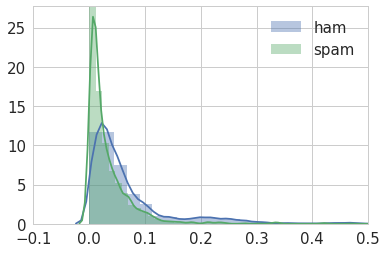

```python
#number of characters in email
training_data = pd.read_csv('data/train.csv')
ham = training_data[training_data['spam'] == 0]
spam = training_data[training_data['spam'] == 1]
ham_len = (ham['subject'].str.len() / ham['email'].str.len()).fillna(0)
spam_len = (spam['subject'].str.len() / spam['email'].str.len()).fillna(0)
#lengths = pd.DataFrame(data = {'ham': ham_len, 'spam': spam_len})
# ham_char = [i / ham['subject'].str.len() for i in ham_len]
# spam_char = (spam_len / ham['subject'].str.len()).fillna(0)
sns.distplot(ham_len, label = 'ham')
sns.distplot(spam_len, label = 'spam')
#(ham['subject'].str.len() / ham['email'].str.len()).fillna(0)
#plt.scatter(ham_len, spam_len)
plt.legend()
plt.xlim(-0.1, 0.5)
```

```python
#number of words in body
ham_word = ham['email'].str.findall('\w+').str.split().str.len()
spam_word = spam['email'].str.findall('\w+').str.split().str.len()
sns.distplot(ham_word)
sns.distplot(spam_word)
plt.xlim(-100, 3000)
```

[output not shown]

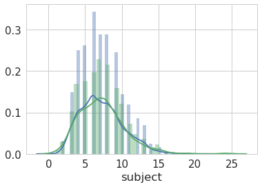

```python
#number of words in subject
ham_subj = ham['subject'].str.findall('\w+').str.len().fillna(0)
spam_subj = spam['subject'].str.findall('\w+').str.len().fillna(0)
sns.distplot(ham_subj)
sns.distplot(spam_subj)
#plt.xlim(-100, 3000)
```

```
(-10, 100)
```

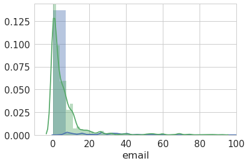

```python
#use of punctuation. How many '!' in body
ham_punc = ham['email'].str.findall('!').str.len()
spam_punc = spam['email'].str.findall('!').str.len()
sns.distplot(ham_punc)
sns.distplot(spam_punc)
plt.xlim(-10, 100)
```

```python
def num_exclamation(data):
    data['num exclamation'] = data['email'].str.findall('!').str.len()
    return data
num_exclamation(train)
```

|  | id | subject | email | spam | num exclamation |
| --- | --- | --- | --- | --- | --- |
| 7657 | 7657 | Subject: Patch to enable/disable log\n | while i was playing with the past issues, it a... | 0 | 2 |
| 6911 | 6911 | Subject: When an engineer flaps his wings\n | url: http://diveintomark.org/archives/2002/10/... | 0 | 0 |
| 6074 | 6074 | Subject: Re: [Razor-users] razor plugins for m... | no, please post a link!\n \n fox\n ----- origi... | 0 | 3 |
| 4376 | 4376 | Subject: NYTimes.com Article: Stop Those Press... | this article from nytimes.com \n has been sent... | 0 | 2 |
| 5766 | 5766 | Subject: What's facing FBI's new CIO? (Tech Up... | <html>\n <head>\n <title>tech update today</ti... | 0 | 44 |
| 5247 | 5247 | Subject: asap\n | --===_secatt_000_1fuklemuttfusq\n content-type... | 1 | 0 |
| 7410 | 7410 | Subject: [use Perl] Headlines for 2002-09-18\n | use perl daily headline mailer\n \n subscribe ... | 0 | 0 |
| 576 | 576 | Subject: Cost price Guinness, Budweiser and se... | ------=_part_2067_1947928.1038245405702\n cont... | 0 | 6 |
| 4398 | 4398 | Subject: Play by Play: Effective Memory Manage... | url: http://www.newsisfree.com/click/-0,861367... | 0 | 0 |
| 3989 | 3989 | Subject: Sheila Lennon was interviewed for the... | url: http://scriptingnews.userland.com/backiss... | 0 | 0 |
| 3686 | 3686 | Subject: Re: Slaughter in the Name of God\n | on tue, 2002-09-17 at 11:16, gary lawrence mur... | 0 | 0 |
| 4509 | 4509 | Subject: Re: RedHat 8.0 and his own freetype\n | on tue, 08 oct 2002 13:05:53 -0700\n ben libli... | 0 | 0 |
| 4176 | 4176 | Subject: PKI smartcard/CA/profile/email/softwa... | has anyone had much positive experience with p... | 0 | 0 |
| 354 | 354 | Subject: Re: Your VIP Pass\n | ###################################\n \n fre... | 1 | 18 |
| 415 | 415 | Subject: Re: Forged whitelist spam\n | > > you mean like on mac keyboards :-)\n \n or... | 0 | 0 |
| 6449 | 6449 | Subject: wives and girlfriends cheating and wh... | <table width="600" border="20" align="center" ... | 1 | 6 |
| 7534 | 7534 | Subject: Lander risks missing Mars trip\n | url: http://www.newsisfree.com/click/-4,805285... | 0 | 0 |
| 7230 | 7230 | Subject: Blair attacks new culture of cynicism\n | url: http://www.newsisfree.com/click/-0,835876... | 0 | 0 |
| 5338 | 5338 | Subject: Fw: Offring Membership To 16 Sites Fo... | <html>\n <head>\n </head>\n <body>\n <center>\... | 1 | 9 |
| 5366 | 5366 | Subject: The Government grants you $25,000!\n | <html>\n <head>\n </head>\n <center>\n <h1>\n ... | 1 | 26 |
| 2692 | 2692 | Subject: I saw your email 7272Gtnz8-338r-13\n | i saw your email on a website i visited yester... | 1 | 4 |
| 177 | 177 | Subject: Re: traceback in new exmh\n | oops - turns out i wasn't careful installing i... | 0 | 0 |
| 7713 | 7713 | Subject: Re: [ILUG] How to copy some files\n | on fri, jul 19, 2002 at 05:06:59pm +0100, matt... | 0 | 0 |
| 1323 | 1323 | Subject: Re: [ILUG] [OT] GPL & PHP Question\n | on sat, jul 20, 2002 at 07:03:17pm +0100, kevi... | 0 | 0 |
| 8316 | 8316 | Subject: Say "Goodbye" to the 9-5 yhe\n | <html>\n <body>\n <p align="center"><b><font s... | 1 | 2 |
| 2372 | 2372 | Subject: New Gunner Gilberto is quick to earn ... | url: http://www.newsisfree.com/click/-6,857278... | 0 | 0 |
| 6207 | 6207 | Subject: Re: [SAtalk] How'd this one slip thro... | rose, bobby wrote:\n > ouch ;-) although i'm ... | 0 | 0 |
| 7851 | 7851 | Subject: [ILUG] $4,000/Month with your PC ! NO... | dear opportunities seekers:\n \n i thought you... | 1 | 1 |
| 7054 | 7054 | Subject: =?big5?Q?=A7K=B6O=B5L=AD=AD=A6=B8=A5=... | this is a multi-part message in mime format.\n... | 1 | 0 |
| 4017 | 4017 | Subject: [SAtalk] [OT] SpamAssassin figures...\n | i finally found the spamassassin ninja's! aft... | 0 | 4 |
| ... | ... | ... | ... | ... | ... |
| 1899 | 1899 | Subject: calling wayne baisley@#!\n | you around?\n c\n \n -- \n "i don't take no st... | 0 | 0 |
| 4658 | 4658 | Subject: ADV: Search Engine Registration\n | to remove see below.\n \n i work with a compan... | 1 | 1 |
| 3005 | 3005 | Subject: Re: "Ouch. Ouch. Ouch. Ouch. Ouch....... | xander blakley quotes a russian joke in his te... | 0 | 0 |
| 2734 | 2734 | Subject: Viridian Note 00328: Fuel from CO2\n | key concepts: nakamichi yamasaki, hydrocarbon... | 0 | 2 |
| 189 | 189 | Subject: i know!!\n | <html>\n <head>\n <title>nasty farm girls!</ti... | 1 | 11 |
| 2747 | 2747 | Subject: Photoshop a kid getting his tounge me... | url: http://www.newsisfree.com/click/-1,838872... | 0 | 0 |
| 2047 | 2047 | Subject: Haunted Mansion movie inches forward\n | url: http://boingboing.net/#85497407\n date: n... | 0 | 2 |
| 7849 | 7849 | Subject: [Spambayes] testing results\n | neil trained a classifier using 3 sets with ab... | 0 | 0 |
| 2558 | 2558 | Subject: Teens videotape themselves shooting s... | url: http://www.newsisfree.com/click/-4,826940... | 0 | 0 |
| 6396 | 6396 | Subject: LIE`S, MIS-INFORMATION and FRAUD\n | \n sent e-mail message \n \n from: enenkio... | 1 | 7 |
| 3385 | 3385 | Subject: CIGARETTES WHOLESALE! HYWWZZLZD\n | $19.95 and up! buy cartons of cigarettes whol... | 1 | 2 |
| 4555 | 4555 | Subject: moooozilla\n | funny load message:\n moo!moo!moo!moo!moo!moo!... | 0 | 12 |
| 1184 | 1184 | Subject: Congrats! Here are your 2 Free Airli... | --##########\n \n see below for your exit info... | 1 | 10 |
| 6420 | 6420 | Subject: Give Away FREE CD's - Earn $5K in 30 ... | this is the bottom line. if you can give away... | 1 | 3 |
| 5051 | 5051 | Subject: Re: apt.conf suggestion\n | once upon a time, ville wrote :\n \n > how abo... | 0 | 1 |
| 5311 | 5311 | Subject: Fw: Impress your friends with your ne... | <!-- saved from url=3d(0022)http://internet.e-... | 1 | 7 |
| 2433 | 2433 | Subject: private\n | ------=_nextpart_000_002b_83a1e322.4d8b344b\n ... | 1 | 0 |
| 6949 | 6949 | Subject: World Wide Words -- 17 Aug 02\n | world wide words issue 303 sa... | 0 | 1 |
| 769 | 769 | Subject: $500,000 Life Policy $9.50 per month.... | <html>\n \n <body>\n \n <font size="2" ptsize=... | 1 | 6 |
| 1685 | 1685 | Subject: Hi Janet, are you going to call me? ... | <html>\n <body bgcolor=3d"#003300">\n <p align... | 1 | 5 |
| 8322 | 8322 | Subject: WWW Form Submission\n | below is the result of your feedback form. it... | 1 | 1 |
| 5578 | 5578 | Subject: Re: [ILUG] Formatting a windows parti... | dublin said:\n > if you copy the files from yo... | 0 | 0 |
| 4426 | 4426 | Subject: cell phone ring tones 84221111000000\n | <html>\n <table width="350" border="0" cellspa... | 1 | 4 |
| 466 | 466 | Subject: Re: [SAtalk] Badly Formatted Spam Rep... | on wed, 11 sep 2002, vince puzzella wrote:\n \... | 0 | 0 |
| 6265 | 6265 | Subject: MY PLEA FOR ASSISTANCE PLEASE\n | \n mr. ayanda maredi\n department of minerals ... | 1 | 0 |
| 5734 | 5734 | Subject: [Spambayes] understanding high false ... | >>>>> "tp" == tim peters <tim.one@comcast.net>... | 0 | 0 |
| 5191 | 5191 | Subject: Reach millions on the internet!!\n | \n dear consumers, increase your business sale... | 1 | 36 |
| 5390 | 5390 | Subject: Facts about sex.\n | \n forwarded-by: flower\n \n did you know that... | 0 | 3 |
| 860 | 860 | Subject: Re: Zoot apt/openssh & new DVD playin... | on tue, oct 08, 2002 at 04:36:13pm +0200, matt... | 0 | 0 |
| 7270 | 7270 | Subject: Re: Internet radio - example from a c... | chris haun wrote:\n > \n > we would need someo... | 0 | 1 |

7513 rows × 5 columns

```
(-100, 50)
```

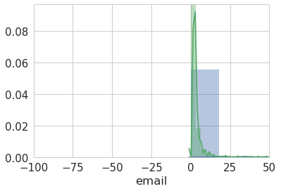

```python
#use of punctuation. How many '<' in body
ham_punc1 = ham['email'].str.findall('@').str.len()
spam_punc1 = spam['email'].str.findall('@').str.len()
sns.distplot(ham_punc1)
sns.distplot(spam_punc1)
plt.xlim(-100, 50)
```

```python
def num_less_than(data):
    data['num less than'] = data['email'].str.findall('<').str.len()
    return data
num_less_than(train)
```

|  | id | subject | email | spam | num exclamation | num less than |
| --- | --- | --- | --- | --- | --- | --- |
| 7657 | 7657 | Subject: Patch to enable/disable log\n | while i was playing with the past issues, it a... | 0 | 2 | 0 |
| 6911 | 6911 | Subject: When an engineer flaps his wings\n | url: http://diveintomark.org/archives/2002/10/... | 0 | 0 | 0 |
| 6074 | 6074 | Subject: Re: [Razor-users] razor plugins for m... | no, please post a link!\n \n fox\n ----- origi... | 0 | 3 | 2 |
| 4376 | 4376 | Subject: NYTimes.com Article: Stop Those Press... | this article from nytimes.com \n has been sent... | 0 | 2 | 0 |
| 5766 | 5766 | Subject: What's facing FBI's new CIO? (Tech Up... | <html>\n <head>\n <title>tech update today</ti... | 0 | 44 | 1008 |
| 5247 | 5247 | Subject: asap\n | --===_secatt_000_1fuklemuttfusq\n content-type... | 1 | 0 | 0 |
| 7410 | 7410 | Subject: [use Perl] Headlines for 2002-09-18\n | use perl daily headline mailer\n \n subscribe ... | 0 | 0 | 0 |
| 576 | 576 | Subject: Cost price Guinness, Budweiser and se... | ------=_part_2067_1947928.1038245405702\n cont... | 0 | 6 | 661 |
| 4398 | 4398 | Subject: Play by Play: Effective Memory Manage... | url: http://www.newsisfree.com/click/-0,861367... | 0 | 0 | 0 |
| 3989 | 3989 | Subject: Sheila Lennon was interviewed for the... | url: http://scriptingnews.userland.com/backiss... | 0 | 0 | 0 |
| 3686 | 3686 | Subject: Re: Slaughter in the Name of God\n | on tue, 2002-09-17 at 11:16, gary lawrence mur... | 0 | 0 | 1 |
| 4509 | 4509 | Subject: Re: RedHat 8.0 and his own freetype\n | on tue, 08 oct 2002 13:05:53 -0700\n ben libli... | 0 | 0 | 2 |
| 4176 | 4176 | Subject: PKI smartcard/CA/profile/email/softwa... | has anyone had much positive experience with p... | 0 | 0 | 0 |
| 354 | 354 | Subject: Re: Your VIP Pass\n | ###################################\n \n fre... | 1 | 18 | 0 |
| 415 | 415 | Subject: Re: Forged whitelist spam\n | > > you mean like on mac keyboards :-)\n \n or... | 0 | 0 | 0 |
| 6449 | 6449 | Subject: wives and girlfriends cheating and wh... | <table width="600" border="20" align="center" ... | 1 | 6 | 37 |
| 7534 | 7534 | Subject: Lander risks missing Mars trip\n | url: http://www.newsisfree.com/click/-4,805285... | 0 | 0 | 0 |
| 7230 | 7230 | Subject: Blair attacks new culture of cynicism\n | url: http://www.newsisfree.com/click/-0,835876... | 0 | 0 | 0 |
| 5338 | 5338 | Subject: Fw: Offring Membership To 16 Sites Fo... | <html>\n <head>\n </head>\n <body>\n <center>\... | 1 | 9 | 371 |
| 5366 | 5366 | Subject: The Government grants you $25,000!\n | <html>\n <head>\n </head>\n <center>\n <h1>\n ... | 1 | 26 | 909 |
| 2692 | 2692 | Subject: I saw your email 7272Gtnz8-338r-13\n | i saw your email on a website i visited yester... | 1 | 4 | 0 |
| 177 | 177 | Subject: Re: traceback in new exmh\n | oops - turns out i wasn't careful installing i... | 0 | 0 | 1 |
| 7713 | 7713 | Subject: Re: [ILUG] How to copy some files\n | on fri, jul 19, 2002 at 05:06:59pm +0100, matt... | 0 | 0 | 0 |
| 1323 | 1323 | Subject: Re: [ILUG] [OT] GPL & PHP Question\n | on sat, jul 20, 2002 at 07:03:17pm +0100, kevi... | 0 | 0 | 0 |
| 8316 | 8316 | Subject: Say "Goodbye" to the 9-5 yhe\n | <html>\n <body>\n <p align="center"><b><font s... | 1 | 2 | 31 |
| 2372 | 2372 | Subject: New Gunner Gilberto is quick to earn ... | url: http://www.newsisfree.com/click/-6,857278... | 0 | 0 | 0 |
| 6207 | 6207 | Subject: Re: [SAtalk] How'd this one slip thro... | rose, bobby wrote:\n > ouch ;-) although i'm ... | 0 | 0 | 0 |
| 7851 | 7851 | Subject: [ILUG] $4,000/Month with your PC ! NO... | dear opportunities seekers:\n \n i thought you... | 1 | 1 | 0 |
| 7054 | 7054 | Subject: =?big5?Q?=A7K=B6O=B5L=AD=AD=A6=B8=A5=... | this is a multi-part message in mime format.\n... | 1 | 0 | 1 |
| 4017 | 4017 | Subject: [SAtalk] [OT] SpamAssassin figures...\n | i finally found the spamassassin ninja's! aft... | 0 | 4 | 0 |
| ... | ... | ... | ... | ... | ... | ... |
| 1899 | 1899 | Subject: calling wayne baisley@#!\n | you around?\n c\n \n -- \n "i don't take no st... | 0 | 0 | 0 |
| 4658 | 4658 | Subject: ADV: Search Engine Registration\n | to remove see below.\n \n i work with a compan... | 1 | 1 | 0 |
| 3005 | 3005 | Subject: Re: "Ouch. Ouch. Ouch. Ouch. Ouch....... | xander blakley quotes a russian joke in his te... | 0 | 0 | 0 |
| 2734 | 2734 | Subject: Viridian Note 00328: Fuel from CO2\n | key concepts: nakamichi yamasaki, hydrocarbon... | 0 | 2 | 12 |
| 189 | 189 | Subject: i know!!\n | <html>\n <head>\n <title>nasty farm girls!</ti... | 1 | 11 | 107 |
| 2747 | 2747 | Subject: Photoshop a kid getting his tounge me... | url: http://www.newsisfree.com/click/-1,838872... | 0 | 0 | 0 |
| 2047 | 2047 | Subject: Haunted Mansion movie inches forward\n | url: http://boingboing.net/#85497407\n date: n... | 0 | 2 | 0 |
| 7849 | 7849 | Subject: [Spambayes] testing results\n | neil trained a classifier using 3 sets with ab... | 0 | 0 | 0 |
| 2558 | 2558 | Subject: Teens videotape themselves shooting s... | url: http://www.newsisfree.com/click/-4,826940... | 0 | 0 | 0 |
| 6396 | 6396 | Subject: LIE`S, MIS-INFORMATION and FRAUD\n | \n sent e-mail message \n \n from: enenkio... | 1 | 7 | 0 |
| 3385 | 3385 | Subject: CIGARETTES WHOLESALE! HYWWZZLZD\n | $19.95 and up! buy cartons of cigarettes whol... | 1 | 2 | 2 |
| 4555 | 4555 | Subject: moooozilla\n | funny load message:\n moo!moo!moo!moo!moo!moo!... | 0 | 12 | 0 |
| 1184 | 1184 | Subject: Congrats! Here are your 2 Free Airli... | --##########\n \n see below for your exit info... | 1 | 10 | 80 |
| 6420 | 6420 | Subject: Give Away FREE CD's - Earn $5K in 30 ... | this is the bottom line. if you can give away... | 1 | 3 | 0 |
| 5051 | 5051 | Subject: Re: apt.conf suggestion\n | once upon a time, ville wrote :\n \n > how abo... | 0 | 1 | 1 |
| 5311 | 5311 | Subject: Fw: Impress your friends with your ne... | <!-- saved from url=3d(0022)http://internet.e-... | 1 | 7 | 157 |
| 2433 | 2433 | Subject: private\n | ------=_nextpart_000_002b_83a1e322.4d8b344b\n ... | 1 | 0 | 0 |
| 6949 | 6949 | Subject: World Wide Words -- 17 Aug 02\n | world wide words issue 303 sa... | 0 | 1 | 9 |
| 769 | 769 | Subject: $500,000 Life Policy $9.50 per month.... | <html>\n \n <body>\n \n <font size="2" ptsize=... | 1 | 6 | 290 |
| 1685 | 1685 | Subject: Hi Janet, are you going to call me? ... | <html>\n <body bgcolor=3d"#003300">\n <p align... | 1 | 5 | 103 |
| 8322 | 8322 | Subject: WWW Form Submission\n | below is the result of your feedback form. it... | 1 | 1 | 4 |
| 5578 | 5578 | Subject: Re: [ILUG] Formatting a windows parti... | dublin said:\n > if you copy the files from yo... | 0 | 0 | 1 |
| 4426 | 4426 | Subject: cell phone ring tones 84221111000000\n | <html>\n <table width="350" border="0" cellspa... | 1 | 4 | 296 |
| 466 | 466 | Subject: Re: [SAtalk] Badly Formatted Spam Rep... | on wed, 11 sep 2002, vince puzzella wrote:\n \... | 0 | 0 | 2 |
| 6265 | 6265 | Subject: MY PLEA FOR ASSISTANCE PLEASE\n | \n mr. ayanda maredi\n department of minerals ... | 1 | 0 | 0 |
| 5734 | 5734 | Subject: [Spambayes] understanding high false ... | >>>>> "tp" == tim peters <tim.one@comcast.net>... | 0 | 0 | 1 |
| 5191 | 5191 | Subject: Reach millions on the internet!!\n | \n dear consumers, increase your business sale... | 1 | 36 | 0 |
| 5390 | 5390 | Subject: Facts about sex.\n | \n forwarded-by: flower\n \n did you know that... | 0 | 3 | 0 |
| 860 | 860 | Subject: Re: Zoot apt/openssh & new DVD playin... | on tue, oct 08, 2002 at 04:36:13pm +0200, matt... | 0 | 0 | 1 |
| 7270 | 7270 | Subject: Re: Internet radio - example from a c... | chris haun wrote:\n > \n > we would need someo... | 0 | 1 | 0 |

7513 rows × 6 columns

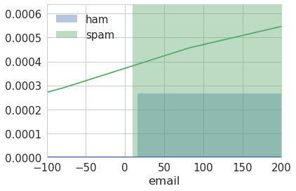

```python
#use of punctuation. How many 'characters' in body
ham_punc2 = ham['email'].str.findall('[^A-Za-z0-9]').str.len()
spam_punc2 = spam['email'].str.findall('[^A-Za-z0-9]').str.len()
sns.distplot(ham_punc2, label = 'ham')
sns.distplot(spam_punc2, label = 'spam')
plt.xlim(-100, 200)
plt.legend()
```

```python
#number of punctuation (not words)
def num_punc(data):
    data['num punc'] = data['email'].str.findall('[^A-Za-z0-9]').str.len()
    return data
```

```python
# def for_re(data):
#     data['num']
train['subject'].str.findall('(Re:) || (Fwd:)').str.len().sum()
```

```
355603.0
```

```python
# #use of punctuation. How many '&' in body
# ham_punc1 = ham['email'].str.findall('<').str.len()
# spam_punc1 = spam['email'].str.findall('<').str.len()
# sns.distplot(ham_punc1)
# sns.distplot(spam_punc1)
# plt.xlim(-100, 1000)
```

```python
#forwarded email
ham_for = ham['subject'].str.findall('Fw:').str.len()
spam_for = spam['subject'].str.findall('Fw:').str.len()
print(ham_for.sum(), spam_for.sum())
#sns.distplot(ham_for)
#sns.distplot(spam_for)
```

```
8.0 27
```

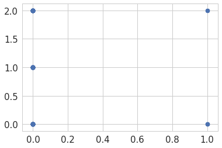

```python
#reply emails
ham_re = ham['subject'].str.findall('Re:').str.len().fillna(0)
spam_re = spam['subject'].str.findall('Re:').str.len().fillna(0)
#sns.distplot(ham_re)
plt.scatter(ham_for, ham_re)
```

```python
new_train = train
new_train['email'] = new_train['email'].str.replace('[^A-Za-z0-9\s]', '') #why are spaces being removed?
new_train['email'][0]
#new_train
```

```
'url httpboingboingnet85534171\n date not supplied\n \n arts and letters daily a wonderful and dense blog has folded up its tent due \n to the bankruptcy of its parent company al daily will be auctioned off by the \n receivers link1 discuss2 thanks misha\n \n 1 httpwwwaldailycom\n 2 httpwwwquicktopi…
```

```python
#keep wordcloud words
#new_training_data = original_training_data[original_training_data['email'].str.findall('!').str.len() > 0]
some_words = ["width", "td", "face", "gif", "font", "face", "img", "src"]

x_train = np.array(words_in_texts(some_words, train['email']))
y_train = train['spam']#"width", "td", "face", "gif", "font", "face", "img", "src"

len(x_train), y_train[:5]
x_train
n = train
n_train = np.array(words_in_texts(some_words, train['email']))
n['word track'] = n_train.tolist()
n['correct words'] = [1 in i for i in n['word track']]
final = n[n['correct words'] == True]
final.drop(['word track', 'correct words'], axis = 1)
#evaluation
```

|  | id | subject | email | spam | num exclamation | num less than |
| --- | --- | --- | --- | --- | --- | --- |
| 4376 | 4376 | Subject: NYTimes.com Article: Stop Those Press... | this article from nytimescom \n has been sent ... | 0 | 2 | 0 |
| 5766 | 5766 | Subject: What's facing FBI's new CIO? (Tech Up... | html\n head\n titletech update todaytitle\n he... | 0 | 44 | 1008 |
| 5247 | 5247 | Subject: asap\n | secatt0001fuklemuttfusq\n contenttype textplai... | 1 | 0 | 0 |
| 576 | 576 | Subject: Cost price Guinness, Budweiser and se... | part206719479281038245405702\n contenttype tex... | 0 | 6 | 661 |
| 6449 | 6449 | Subject: wives and girlfriends cheating and wh... | table width600 border20 aligncenter bordercolo... | 1 | 6 | 37 |
| 5338 | 5338 | Subject: Fw: Offring Membership To 16 Sites Fo... | html\n head\n head\n body\n center\n table bor... | 1 | 9 | 371 |
| 5366 | 5366 | Subject: The Government grants you $25,000!\n | html\n head\n head\n center\n h1\n bfont facea... | 1 | 26 | 909 |
| 2692 | 2692 | Subject: I saw your email 7272Gtnz8-338r-13\n | i saw your email on a website i visited yester... | 1 | 4 | 0 |
| 177 | 177 | Subject: Re: traceback in new exmh\n | oops turns out i wasnt careful installing it ... | 0 | 0 | 1 |
| 8316 | 8316 | Subject: Say "Goodbye" to the 9-5 yhe\n | html\n body\n p aligncenterbfont size5 colorff... | 1 | 2 | 31 |
| 7851 | 7851 | Subject: [ILUG] $4,000/Month with your PC ! NO... | dear opportunities seekers\n \n i thought you ... | 1 | 1 | 0 |
| 7054 | 7054 | Subject: =?big5?Q?=A7K=B6O=B5L=AD=AD=A6=B8=A5=... | this is a multipart message in mime format\n \... | 1 | 0 | 1 |
| 5948 | 5948 | Subject: HGH Myth --- Learn the Truth\n | htmlbody onloadwindowopenhttp2021011633481ulti... | 1 | 12 | 95 |
| 3826 | 3826 | Subject: Movies to Watch on Lifetime\n | lifetime movie newsletter\n \n this weeks movi... | 0 | 6 | 0 |
| 4953 | 4953 | Subject: [ILUG] ASSISTANCE\n | from col michael bundu \n democratic republic ... | 1 | 0 | 0 |
| 1426 | 1426 | Subject: Vary your interests!\n | \n \n \n \n httpwwwwebheadsweeklycombabessh... | 1 | 70 | 2 |
| 2874 | 2874 | Subject: [ILUG] Dialup on debian\n | hi all\n \n i have a debian machine with an ex... | 0 | 0 | 2 |
| 8239 | 8239 | Subject: Telecom Consolidation Begins to Accel... | html\n head\n titleigtttitle\n meta httpequivc... | 1 | 3 | 233 |
| 5925 | 5925 | Subject: Introducing HGH: The Most Powerful An... | htmlbody onloadwindowopenhttp2021011633481ulti... | 1 | 16 | 97 |
| 3739 | 3739 | Subject: Online Credit Repair,Approved by Bure... | htmlheadtitlecreditfixtitle \n headbody bgcolo... | 1 | 0 | 82 |
| 7662 | 7662 | Subject: zzzz,Hello\n | are you tired of spending a fortune on printer... | 1 | 4 | 0 |
| 7236 | 7236 | Subject: RE: Reduce Your Home Loan Payment $50... | html\n \n body\n \n font size2 ptsize10\n tabl... | 1 | 6 | 202 |
| 7566 | 7566 | Subject: Top Seed #574A\n | 76ad\n this is a mime message\n \n nextpart000... | 1 | 15 | 533 |
| 5927 | 5927 | Subject: Re: [SAdev] SpamAssassin v2.40 releas... | \n ejnrukwclwjh1khz\n contenttype textplain ch... | 0 | 0 | 1 |
| 5141 | 5141 | Subject: Order your Viagra and weight-loss her... | html\n \n head\n meta httpequivcontenttype con... | 1 | 7 | 99 |
| 2374 | 2374 | Subject: Take your Marketing to the Next Level\n | html\n head\n titledigital publishing tools f... | 1 | 6 | 156 |
| 217 | 217 | Subject: CNET: Copycat worms and a PGP Outlook... | html\n head\n \ttitlecnet virus security news... | 0 | 18 | 686 |
| 4691 | 4691 | Subject: Increase Length And Thickness ... | html\n head\n head\n body\n font size3d4b a ma... | 1 | 0 | 16 |
| 4755 | 4755 | Subject: A Situation That Could Revolutionize ... | date tuesday july 9 2002brbr\n brdoctype html ... | 1 | 2 | 325 |
| 308 | 308 | Subject: Is Neotropin right for you?\n | htmlbodycentera hrefhttpwwwvitafactorycomimg s... | 1 | 0 | 32 |
| ... | ... | ... | ... | ... | ... | ... |
| 7215 | 7215 | Subject: Why we're changing our publishing sch... | \n \n \n html\n head\n titlez... | 0 | 10 | 351 |
| 6184 | 6184 | Subject: Re: [ILUG] inputting chinese characte... | on wed jul 31 2002 at 065750pm 0100 brian fost... | 0 | 1 | 2 |
| 5258 | 5258 | Subject: [Spambayes] timtest broke?\n | \n after my latest cvs up timtest fails with\n... | 0 | 0 | 0 |
| 2695 | 2695 | Subject: Membership Status Notification\n | dear free member\n \n you were gifted a free m... | 1 | 0 | 0 |
| 2027 | 2027 | Subject: Wait too long AND... 1147\n | html\n body bgcolor3dffffff text3d000000\n tab... | 1 | 0 | 48 |
| 5463 | 5463 | Subject: RE: International Real Estate - Huge ... | \n \n \n \n \n html\n head\n titleweb letterti... | 1 | 7 | 223 |
| 2568 | 2568 | Subject: Re: Ink Prices Got You Down? ... | html\n \n head\n meta httpequiv3dcontentlangua... | 1 | 6 | 182 |
| 7208 | 7208 | Subject: FOAF explorer\n | url httpdiveintomarkorgarchives20020925htmlfoa... | 0 | 0 | 0 |
| 7916 | 7916 | Subject: Blue horseshoe meet me\n | this is a multipart message in mime format\n \... | 1 | 7 | 31 |
| 6863 | 6863 | Subject: Goats with enormous testicles, and a ... | url httpboingboingnet85482924\n date not suppl... | 0 | 1 | 0 |
| 995 | 995 | Subject: Save an extra $50 on the iPaq 3835 PD... | \n html\n head\n \ttitleshopper newsletter ale... | 0 | 34 | 690 |
| 5675 | 5675 | Subject: RE: Important Information Concerning ... | tired of the bull out there\n want to stop los... | 1 | 55 | 0 |
| 3843 | 3843 | Subject: NEWS.COM INVESTOR: Techs rise, but Do... | html\n head\n titlecnet investor dispatchtitle... | 0 | 36 | 1049 |
| 3943 | 3943 | Subject: Excellent Tim Biskup card deck\n | url httpboingboingnet85538898\n date not suppl... | 0 | 1 | 0 |
| 3152 | 3152 | Subject: Mortgage Rates Have Never Been Lower\n | this is a multipart message in mime format\n \... | 1 | 11 | 207 |
| 8226 | 8226 | Subject: Today's Special: Amazing Penetrations... | htmlbodycenter\n \n table bgcolor3d663399 bord... | 1 | 10 | 177 |
| 7041 | 7041 | Subject: All Satellite Channels Free !! ... | \n html\n body\n \n font size3d5font color3dre... | 1 | 2 | 72 |
| 2612 | 2612 | Subject: Make $500 - $2500/Week on Ebay ... | html\n body\n head\n \n body bgcolor3dffffff\n... | 1 | 2 | 93 |
| 7734 | 7734 | Subject: You're Invited!\n | this is a multipart message in mime format\n \... | 1 | 21 | 256 |
| 2734 | 2734 | Subject: Viridian Note 00328: Fuel from CO2\n | key concepts nakamichi yamasaki hydrocarbon\n... | 0 | 2 | 12 |
| 189 | 189 | Subject: i know!!\n | html\n head\n titlenasty farm girlstitle\n met... | 1 | 11 | 107 |
| 2047 | 2047 | Subject: Haunted Mansion movie inches forward\n | url httpboingboingnet85497407\n date not suppl... | 0 | 2 | 0 |
| 2558 | 2558 | Subject: Teens videotape themselves shooting s... | url httpwwwnewsisfreecomclick482694061717\n da... | 0 | 0 | 0 |
| 6396 | 6396 | Subject: LIE`S, MIS-INFORMATION and FRAUD\n | \n sent email message \n \n from enenkiowe... | 1 | 7 | 0 |
| 1184 | 1184 | Subject: Congrats! Here are your 2 Free Airli... | \n \n see below for your exit information\n \n... | 1 | 10 | 80 |
| 5311 | 5311 | Subject: Fw: Impress your friends with your ne... | saved from url3d0022httpinternetemail \n doct... | 1 | 7 | 157 |
| 769 | 769 | Subject: $500,000 Life Policy $9.50 per month.... | html\n \n body\n \n font size2 ptsize10\n tabl... | 1 | 6 | 290 |
| 1685 | 1685 | Subject: Hi Janet, are you going to call me? ... | html\n body bgcolor3d003300\n p align3dcenterf... | 1 | 5 | 103 |
| 5578 | 5578 | Subject: Re: [ILUG] Formatting a windows parti... | dublin said\n if you copy the files from your... | 0 | 0 | 1 |
| 4426 | 4426 | Subject: cell phone ring tones 84221111000000\n | html\n table width350 border0 cellspacing0 cel... | 1 | 4 | 296 |

2344 rows × 6 columns

```python
def choose_words(data):
    some_words = ["width", "td", "face", "size", "font", "face", "color", "3D", "tr", "BR", "nbsp", "body", "business", "money", "offer", "please"]
    words = np.array(words_in_texts(some_words, data['email']))
    data['word track'] = [sum(i) for i in words]
#     data['word track'] = words.tolist()
#     data['correct words'] = [1 in i for i in data['word track']]
#     data = data[data['correct words'] == True]
#     data = data.drop(['word track', 'correct words'], axis = 1)
    return data
#choose_words(train)
```

```python
from sklearn.linear_model import LogisticRegression

some_words = ["width", "td", "face", "gif", "font", "face", "img", "src"]

x_train = np.array(words_in_texts(some_words, train['email']))

lr = LogisticRegression()

lr.fit(x_train, y_train)

x_eval_train = np.array(words_in_texts(some_words, evaluation['email']))
y_pred = lr.predict(x_eval_train)
training_accuracy = lr.score(x_eval_train, y_pred)
training_accuracy
x_train
#y_pred.sum()
#evaluation
# from sklearn.svm import LinearSVC
# from sklearn.datasets import load_iris
# from sklearn.feature_selection import SelectFromModel
# #X, y = iris.data, iris.target
# lsvc = LinearSVC(C=0.01, penalty="l1", dual=False).fit(x_train, y_train)
# model = SelectFromModel(lsvc, prefit=True)
# X_new = model.transform(x_train)
# model.score(x_train, y_train)
```

```
array([[0, 0, 0, ..., 0, 0, 0],
       [0, 0, 0, ..., 0, 0, 0],
       [0, 0, 0, ..., 0, 0, 0],
       ...,
       [0, 0, 0, ..., 0, 0, 0],
       [0, 0, 0, ..., 0, 0, 0],
       [0, 0, 0, ..., 0, 0, 0]])
```

```python
def select_columns(data, *columns):
    return data.loc[:, columns]
```

```python
def capital_letter_ratio(data):

    # YOUR CODE HERE
    data['proportion_low'] = data['email'].str.findall('[A-Z]').str.len() / data['email'].str.findall('[a-zA-Z]').str.len()
    return data

#raise NotImplementedError()
```

```python
def lowercase_letter_ratio(data):

    # YOUR CODE HERE
    data['proportion_caps'] = data['email'].str.findall('[a-z]').str.len() / data['email'].str.findall('[a-zA-Z]').str.len()
    return data
```

```python
#Kaggle Submission Model
from sklearn.linear_model import LogisticRegression
some_words = ["width", "td", "face", "size", "font", "face", "color", "3D", "tr", "br", "nbsp"]
def process_data_fm(data):
    data = (
        data
        # Clean Data
        .pipe(choose_words)
        .pipe(remove_html)

        # Transform data
        .pipe(num_exclamation)
        .pipe(num_punc)
        .pipe(num_less_than)
        .pipe(capital_letter_ratio) #improved accuracy. 72 --> 80
        .pipe(select_columns,
             'spam',
             'num exclamation',
             'num punc',
             'num less than',
             'proportion_caps',
             'proportion_low'
             )
     )

    data = data.fillna(0)
    X = data.drop(['spam'], axis = 1)#.fillna(0)
    y = data['spam']
    return X, y


final_model = LogisticRegression(penalty = 'l1')
original_training_data = pd.read_csv('data/train.csv')

train, test = train_test_split(original_training_data, test_size=0.2)
x_train, y_train = process_data_fm(train)
final_model.fit(x_train, y_train)
y_predicted_train = final_model.predict_proba(x_train)

train_accuracy = final_model.score(x_train, y_train)
train_accuracy
# evaluation_predictions = final_model.predict(process_data_fm(evaluation)[0])
# evaluation_predictions
# training_accuracy = lr.score(Phi_train, Y_train)
```

```
0.79799341120095835
```

# Question 7 (Feature/Model Selection Process)

# Question 8 (EDA)

In the two cells below, show a visualization that you used to select features for your model. Include both

1. A plot showing something meaningful about the data that helped you during feature / model selection.
2. 2-3 sentences describing what you plotted and what its implications are for your features.

Feel to create as many plots as you want in your process of feature selection, but select one for the cells below.

**You should not show us a visualization just like in question 3.** Specifically, don't show us a bar chart of proportions, or a one-dimensional class conditional density plot. Any other plot is acceptable, as long as it comes with thoughtful commentary. Here are some ideas:

1. Consider the correlation between multiple features (look up correlation plots and `sns.heatmap`).
2. Try to show redundancy in a group of features (e.g. `body` and `html` might co-occur relatively frequently, or you might be able to design a feature that captures all html tags and compare it to these).
3. Use a word-cloud or another visualization tool to characterize the most common spam words.
4. Visually depict whether spam emails tend to be wordier (in some sense) than ham emails.

[output not shown]

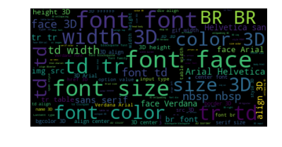

```python
# YOUR CODE HERE
!pip install WordCloud
from os import path
from wordcloud import WordCloud

spam_email = train[train['spam'] == 1]['email']
# Read the whole text.
#text = open('data/train.csv').read()
#text2 = pd.read_csv('data/train.csv', usecols=['email'])

# Generate a word cloud image
#wordcloud = WordCloud().generate(text)
wordcloud = WordCloud().generate(' '.join(spam_email))

# lower max_font_size
wordcloud = WordCloud(max_font_size=40).generate(' '.join(spam_email))
plt.figure()
plt.imshow(wordcloud, interpolation="bilinear")
plt.axis("off")
plt.show()
# #raise NotImplementedError()
```

# Question 9 (Making a Precision-Recall Curve)

We can trade off between precision and recall. In most cases we won't be able to get both perfect precision (i.e. no false positives) and recall (i.e. no false negatives), so we have to compromise. For example, in the case of cancer screenings, false negatives are comparatively worse than false positives — a false negative means that a patient might not discover a disease until it's too late to treat, while a false positive means that a patient will probably have to take another screening.

Recall that logistic regression calculates the probability that an example belongs to a certain class. Then, to classify an example we say that an email is spam if our classifier gives it $\ge 0.5$ probability of being spam. However, *we can adjust that cutoff*: we can say that an email is spam only if our classifier gives it $\ge 0.7$ probability of being spam, for example. This is how we can trade off false positives and false negatives.

The precision-recall curve shows this trade off for each possible cutoff probability. In the cell below, [plot a precision-recall curve](http://scikit-learn.org/stable/auto_examples/model_selection/plot_precision_recall.html#plot-the-precision-recall-curve) for your final classifier (the one you use to make predictions for Kaggle).

```
Text(0.5,1,'2-class Precision-Recall curve: AP=0.64')
```

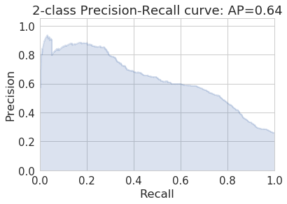

```python
from sklearn.metrics import precision_recall_curve

# Note that you'll want to use the .predict_proba(...) method for your classifier
# instead of .predict(...) so you get probabilities, not classes

import matplotlib.pyplot as plt
from sklearn.metrics import average_precision_score

y_score = final_model.decision_function(x_train)
average_precision = average_precision_score(y_train, y_score)

precision, recall, _ = precision_recall_curve(y_train, y_score)

plt.step(recall, precision, color='b', alpha=0.2,
         where='post')
plt.fill_between(recall, precision, step='post', alpha=0.2,
                 color='b')

plt.xlabel('Recall')
plt.ylabel('Precision')
plt.ylim([0.0, 1.05])
plt.xlim([0.0, 1.0])
plt.title('2-class Precision-Recall curve: AP={0:0.2f}'.format(
          average_precision))

#raise NotImplementedError()
```

# Question 10: Submitting to Kaggle

The following code will write your predictions on the evaluation dataset to a CSV, which you can submit to Kaggle. You may need to modify it to suit your needs.

Save your predictions in a 1-dimensional array called `evaluation_predictions`. *Even if you are not submitting to Kaggle, please make sure you've saved your predictions to `evaluation_predictions` as this is how your grade for this part will be determined.*

Remember that if you've performed transformations or featurization on the training data, you must also perform the same transformations on the evaluation data in order to make predictions. For example, if you've created features for the words "drug" and "money" on the training data, you must also extract the same features in order to use scikit-learn's `.predict(...)` method.

You should submit your CSV files to https://www.kaggle.com/t/39fae66747b14fd48fe0984f2e4f16ac

```python
# CHANGE ME (Currently making random predictions)
evaluation_predictions = final_model.predict(process_data_fm(evaluation)[0])

# YOUR CODE HERE
#raise NotImplementedError()
```

```python
# must be ndarray of predictions
assert isinstance(evaluation_predictions, np.ndarray)

# must be binary labels (0 or 1) and not probabilities
assert np.all((evaluation_predictions == 0) | (evaluation_predictions == 1))

# must be the right number of predictions
assert evaluation_predictions.shape == (1000, )
```

```python
# Please do not modify this cell
```

The following saves a file to submit to Kaggle.

```python
from datetime import datetime

# Assuming that your predictions on the evaluation set are stored in a 1-dimensional array called
# evaluation_predictions. Feel free to modify this cell as long you create a CSV in the right format.

# must be ndarray of predictions
assert isinstance(evaluation_predictions, np.ndarray)

# must be binary labels (0 or 1) and not probabilities
assert np.all((evaluation_predictions == 0) | (evaluation_predictions == 1))

# must be the right number of predictions
assert evaluation_predictions.shape == (1000, )

# Construct and save the submission:
submission_df = pd.DataFrame({
    "Id": evaluation['id'],
    "Class": evaluation_predictions,
}, columns=['Id', 'Class'])
timestamp = datetime.isoformat(datetime.now()).split(".")[0]
submission_df.to_csv("submission_{}.csv".format(timestamp), index=False)

print('Created a CSV file: {}.'.format("submission_{}.csv".format(timestamp)))
print('You may now upload this CSV file to Kaggle for scoring.')
```

```
Created a CSV file: submission_2018-04-30T20:40:33.csv.
You may now upload this CSV file to Kaggle for scoring.
```